# Usage of Bike Sharing Platforms

## by Ryo Shibata

## Investigation Overview

> In this investigation I wanted to look for differences between in gender and user type in the usage of the bike sharing platform. I focused on the proportions over weekdays and day time and compared the differences in the average trip durations

## Dataset Overview

> The dataset consists of two datasets of two different cities; San Francisco and Chicago. There are 268465 individuals rides recorded from the Ford GoBike System (San Francisco) and the Divvy Trips System (Chicago). The data gives insights about the duration of a ride, the gender, user type and the birth year. Furthermore there are information about the trip distance in the San Francisco dataset.

## Distribution of Gender and User Types

> In dataset are more records about male than female users. About 77% of the users are male.

> Usually the users are subscribers (94 % of all users)

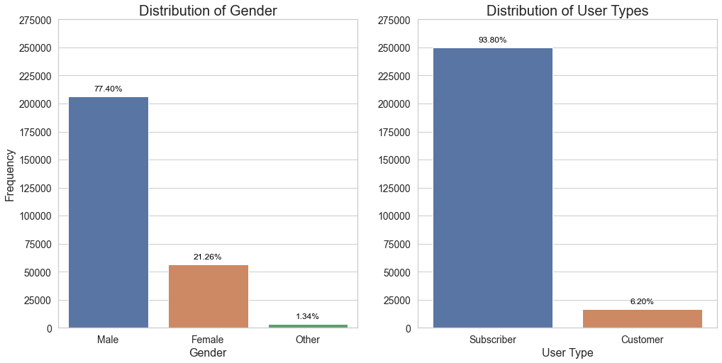

## Average Trip Duration over Weekday for each gender

> In average male users takes less minutes per trip than female or others. Usually male users need less than 10 minutes for their trip on workdays. Female users about 11 minutes. on weekends all genders take longer trips.

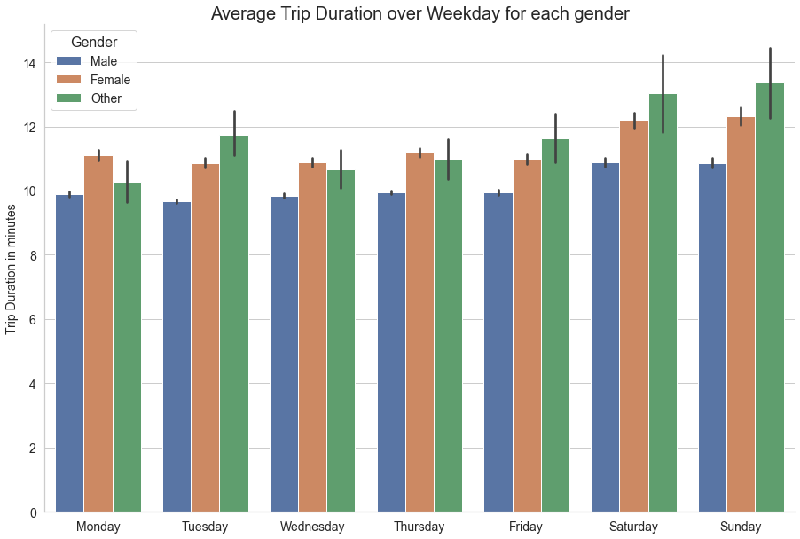

## Relative Distribtion of User Types over Weekday

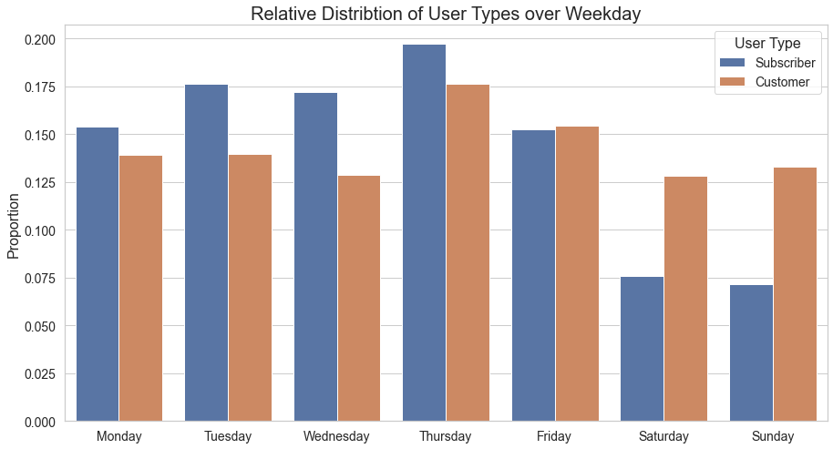

## Average Trip Duration over Weekday for each User Type

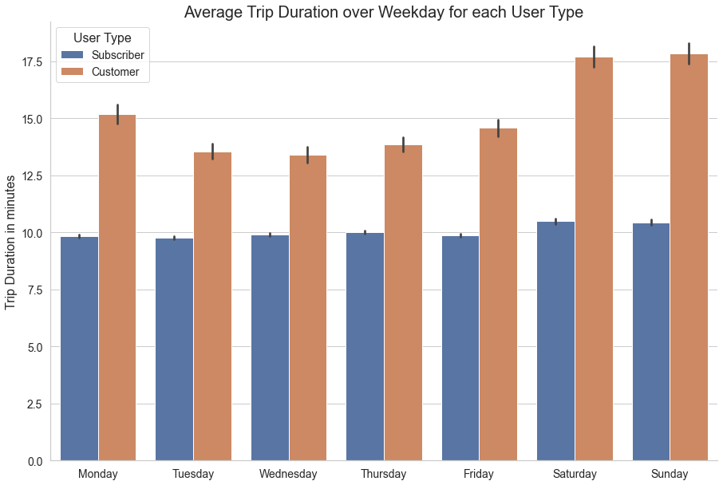